# PLSC 30600 - Lab 6 - Instrumental Variables

02/11/2023

# Acemoglu et al. (2001): The Effect of Institutions on Economic Development

This is a classic piece on studying the causal effect of institutions on economic development.

The key variables in this paper are:

- `logpgp95` - Outcome: Log GDP Per Capita, PPP, 1995
- `avexpr` - Treatment: Average Protection-Expropriation Risk 1985-95
- `logem4` - Instrument: Log of Settler Mortality

Note: The avexpr is the average protection against expropriation risk measured on a scale from 0-10, where a higher score means more protection against expropriation.

To address the endogeneity problem of institution, Acemoglu et al. (2001) uses an IV strategy to isolate exogenous variations in institutions. The instrument is the settler mortality. The idea of the instrument is the following. If the settler mortality is low, Europeans migrated and settled in those colonies and created “Neo-Europes”, which replicated European institutions with strong emphasis on private property and checks against government power. If the settler mortality is high, Europeans set up “extractive states” which does not introduce much protection for private property, nor did they provide checks and balances against government power.

## Figure 1: Reduced-Form Relationship

We first reproduce Figure 1, which is the reduced form relationship between log settler mortality and income. From the figure, we see a negative correlation here, the higher the settler mortality, the lower the income in 1995.

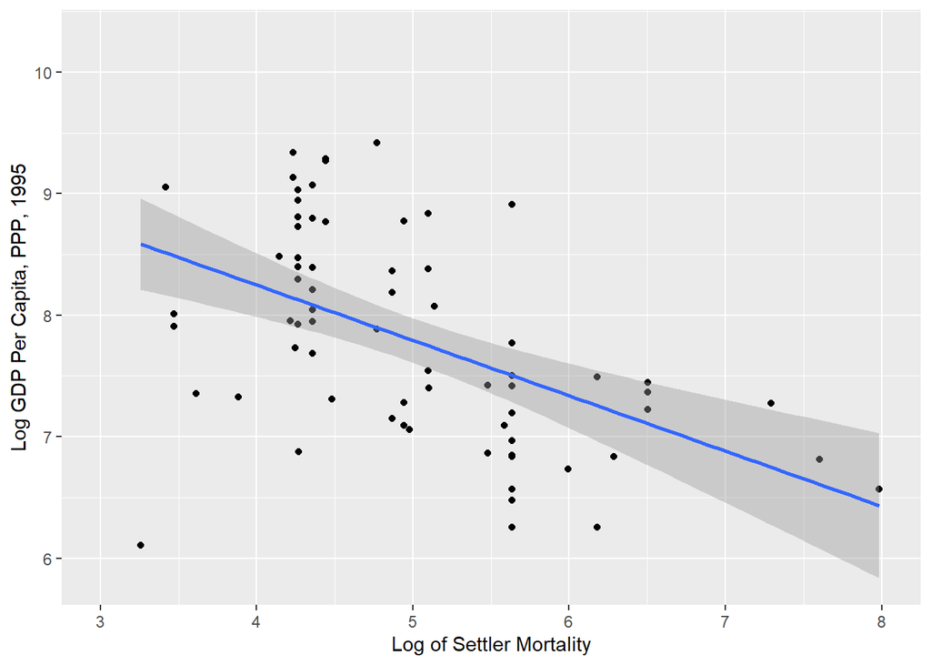

```r
# read data
fig1_dta <- read_dta("maketable3.dta")

# make figure
fig1_dta %>% ggplot(aes(x = logem4, y = logpgp95)) +
  geom_point() +
  geom_smooth(method="lm", formula = y ~ x) +
  xlab("Log of Settler Mortality") +
  xlim(3, 8) +
  ylab("Log GDP Per Capita, PPP, 1995")
```

## Figure 2: First Stage Plot - Correlation between the protection-expropiation risk and mortality

We now reproduce Figure 2. The figure shows a negative correlation between log settler mortality and institutional quality.

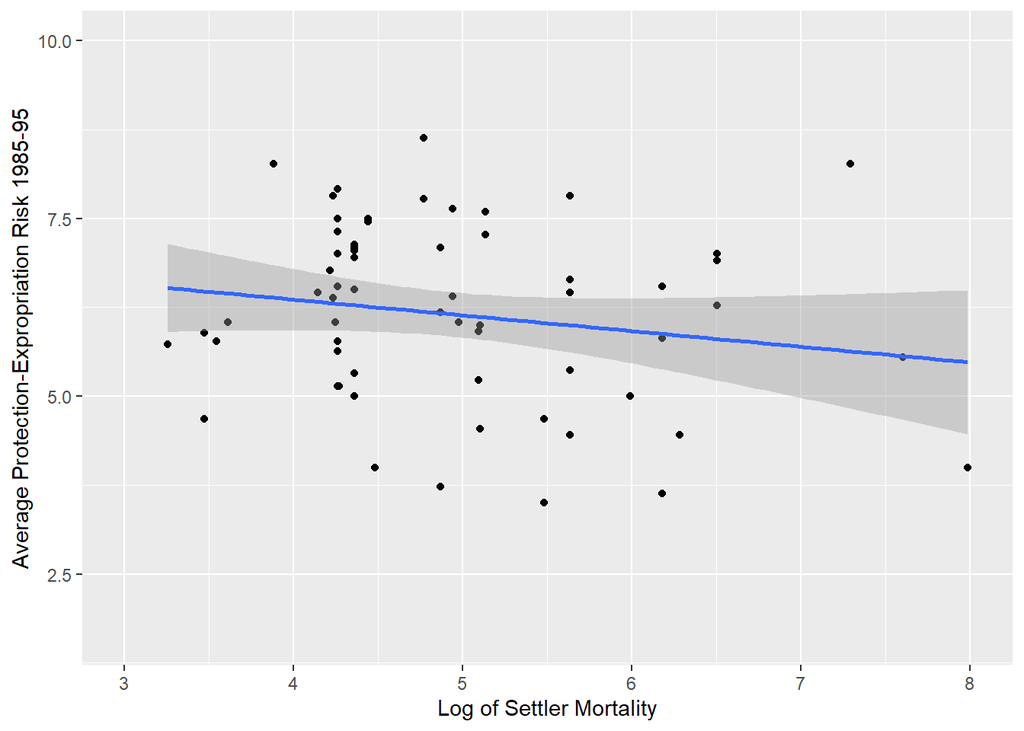

```r
# read data
fig2_dta <- read_dta("maketable3.dta")

# make figure
fig2_dta %>% ggplot(aes(x = logem4, y = avexpr)) +
  geom_point() +
  geom_smooth(method="lm", formula = y ~ x) +
  xlab("Log of Settler Mortality") +
  xlim(3, 8) +
  ylab("Average Protection-Expropriation Risk 1985-95")
```

## Figure 3: Second Stage plot - Correlation between protection-expropriation risk and income

We now reproduce Figure 3, which is the raw correlation between protection-expropriation risk and income. From the figure, we observe a strong positive correlation between institution quality and economic development.

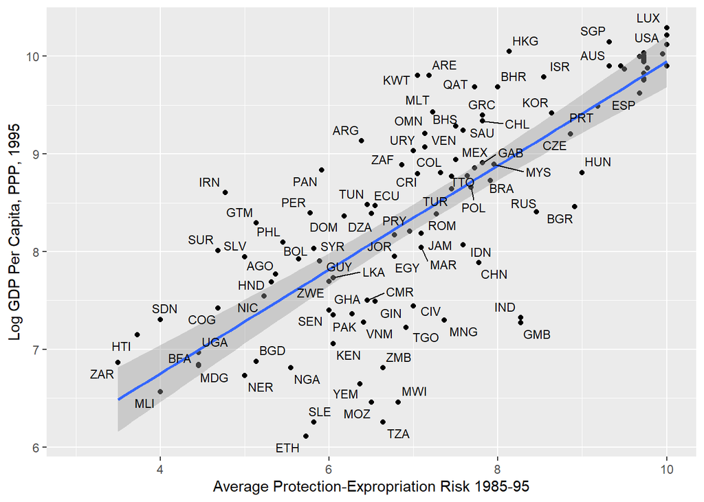

```r
# read data
fig3_dta <- read_dta("maketable2.dta")

# make figure
fig3_dta %>% ggplot(aes(x = avexpr, y = logpgp95)) +
  geom_point() +
  geom_smooth(method="lm", formula = y ~ x) +
  geom_text_repel(aes(label = shortnam), size = 3) +
  xlab("Average Protection-Expropriation Risk 1985-95") +
  xlim(3, 10) +
  ylab("Log GDP Per Capita, PPP, 1995")
```

## Table 4: Baseline IV Results

We now use the ivmodel package and AER package to replicate Column (1) in Table 4 in Acemoglu et al. (2001). The results are qualitatively the same with the original results, and the sample size is slightly different. Note that ivmodel reports the Anderson-Rubin test results. The test is robust to weak identification, i.e., when IV is weak. The idea is based on inverting the test. For a testbook treatment of the AR test, see section 5.1 in Andrews et al. (2019).

```r
# read data
tab4_dta <- read_dta("maketable4.dta")
tab4_dta_full <- tab4_dta[complete.cases(tab4_dta),]

# use ivmodel package to reproduce IV estimates
outcome <- as.numeric(tab4_dta$logpgp95)
treatment <- as.numeric(tab4_dta$avexpr)
instrument <- as.numeric(tab4_dta$logem4)

ajr_iv_ivmodel <- ivmodel(Y = outcome, D = treatment, Z = instrument)
ajr_iv_ivmodel
```

```
##
## Call:
## ivmodel(Y = outcome, D = treatment, Z = instrument)
## sample size: 70
## _ _ _ _ _ _ _ _ _ _ _ _ _ _ _ _ _ _ _ _ _ _ _ _ _ _ _ _ _ _
##
## First Stage Regression Result:
##
## F=29.79835, df1=1, df2=68, p-value is 7.2947e-07
## R-squared=0.3046917,   Adjusted R-squared=0.2944666
## Residual standard error: 1.304066 on 69 degrees of freedom
## _ _ _ _ _ _ _ _ _ _ _ _ _ _ _ _ _ _ _ _ _ _ _ _ _ _ _ _ _ _
##
## Coefficients of k-Class Estimators:
##
##              k Estimate Std. Error t value Pr(>|t|)
## OLS    0.00000  0.51581    0.05416   9.523 3.86e-14 ***
## Fuller 0.98529  0.85193    0.12079   7.053 1.14e-09 ***
## TSLS   1.00000  0.86839    0.12501   6.946 1.77e-09 ***
## LIML   1.00000  0.86839    0.12501   6.946 1.77e-09 ***
## ---
## Signif. codes:  0 '***' 0.001 '**' 0.01 '*' 0.05 '.' 0.1 ' ' 1
## _ _ _ _ _ _ _ _ _ _ _ _ _ _ _ _ _ _ _ _ _ _ _ _ _ _ _ _ _ _
##
## Alternative tests for the treatment effect under H_0: beta=0.
##
## Anderson-Rubin test (under F distribution):
## F=66.26733, df1=1, df2=68, p-value is 1.2178e-11
## 95 percent confidence interval:
##  [0.667419650762224, 1.22579151622886]
##
## Conditional Likelihood Ratio test (under Normal approximation):
## Test Stat=66.26733, p-value is 1.2178e-11
## 95 percent confidence interval:
##  [0.66741956284952, 1.22579179425028]
```

```r
# use AER package to reproduce IV estimates
ajr_iv_aer <- ivreg(logpgp95 ~ avexpr | logem4, data = tab4_dta)
summary(ajr_iv_aer)
```

```
##
## Call:
## ivreg(formula = logpgp95 ~ avexpr | logem4, data = tab4_dta)
##
## Residuals:
##      Min       1Q   Median       3Q      Max
## -2.28175 -0.55059  0.03401  0.62273  1.57418
##
## Coefficients:
##             Estimate Std. Error t value Pr(>|t|)
## (Intercept)   2.3702     0.8376   2.830  0.00612 **
## avexpr        0.8684     0.1250   6.946 1.77e-09 ***
## ---
## Signif. codes:  0 '***' 0.001 '**' 0.01 '*' 0.05 '.' 0.1 ' ' 1
##
## Residual standard error: 0.8899 on 68 degrees of freedom
## Multiple R-Squared: 0.3045,  Adjusted R-squared: 0.2942
## Wald test: 48.25 on 1 and 68 DF,  p-value: 1.771e-09
```

```r
ajr_iv_aer_coef <- ivreg(logpgp95 ~ avexpr | logem4,
                         data = tab4_dta)$coefficients[2]
ajr_iv_aer_coef
```

```
##    avexpr
## 0.8683933
```

## One More Remark on Acemoglu et al. (2001)

Acemoglu et al. (2001) does not give the IV estimator a LATE type interpretation. What deviates from the baseline IV model is that the treatment is not binary. However, we still can extend the LATE framework to the case when the treatment is non-binary. As far as I know, the following paper, Masten and Torgovitsky (2016), is relevant.

## Do Not Compute the Bootstrap Standard Error for Instrumental Variable

Hahn and Liao (2021) shows that the boostrap standard error is usually too ``large’’, in their simulation, they use an exact identified IV model to illustrate the theoretical point. Moreover, infinite samples the 2SLS estimator may not have a finite second moment, which implies that bootstrap standard error estimates are unstable and unreliable (Hansen, 2021). Let us now see how things goes in Acemoglu et al. (2001) data. In this example, the bootstrap standard error is around 1.6 times as large as the standard error reported in AER/ivmodel package (0.2037 vs. 0.1250).

```r
# set seed to make results replicable
set.seed(60637)

# create bootstrap vector
n_iteration <- 5000
iv_boot <- rep(NA, n_iteration)

# bootstrap iteration
for(i in 1:n_iteration){

  # resample with replacement
  tab4_dta_boot <- tab4_dta[sample(1:nrow(tab4_dta),
                                   nrow(tab4_dta),
                                   replace=T),]

  # run iv model using AER package with the bootstrap data
  iv <- ivreg(logpgp95 ~ avexpr | logem4, data = tab4_dta_boot)$coefficients[2]
  iv_boot[i] <- iv

}

# display bootstrap standard error and associated confidence interval
boot_iv_se <- sd(iv_boot)
boot_iv_se
```

```
## [1] 0.2036732
```

```r
c(ajr_iv_aer_coef - qnorm(.975)*boot_iv_se,
  ajr_iv_aer_coef + qnorm(.975)*boot_iv_se)
```

```
##    avexpr    avexpr
## 0.4692013 1.2675854
```

```r
# bootstrap percentile method
quantile(iv_boot, c(0.025, 0.975))
```

```
##      2.5%     97.5%
## 0.6735169 1.3722130
```

```r
# compare with the CI from AER package
c(ajr_iv_aer_coef - qnorm(.975)*0.1250,
  ajr_iv_aer_coef + qnorm(.975)*0.1250)
```

```
##    avexpr    avexpr
## 0.6233978 1.1133888
```

## References

Acemoglu, Daron, Simon Johnson, and James A. Robinson. “The colonial origins of comparative development: An empirical investigation.” American Economic Review 91, no. 5 (2001): 1369-1401.

Andrews, Isaiah, James H. Stock, and Liyang Sun. “Weak instruments in instrumental variables regression: Theory and practice.” Annual Review of Economics 11 (2019): 727-753.

Hahn, Jinyong, and Zhipeng Liao. “Bootstrap standard error estimates and inference.” Econometrica 89, no. 4 (2021): 1963-1977.

Hansen, Bruce. “Econometrics.” Unpublished Manuscript, (2021).

Masten, Matthew A., and Alexander Torgovitsky. “Identification of instrumental variable correlated random coefficients models.” Review of Economics and Statistics 98, no. 5 (2016): 1001-1005.